# Popdemos Pretest

# Introduction

Pretest for POPDEMOS Project that explores the relationship between depictions of fear/anxiety and anger for outgroups, especially right-wing populist groups.

Analysis run on 2020-06-07.

# Setup and Data Cleaning

See code from Alex in popemo_script.R for labeling and recoding. Cannot share data due to privacy concerns. Maybe add a synthetic data set for validation?

# Descriptives

### Left-Right Self placement

```r
df %>%
  mutate(lr=unclass(links_rechts))%>%
  select(lr)%>%
  summary(.)
```

```
##        lr
##  Min.   : 0.000
##  1st Qu.: 4.000
##  Median : 5.000
##  Mean   : 5.199
##  3rd Qu.: 6.000
##  Max.   :10.000
```

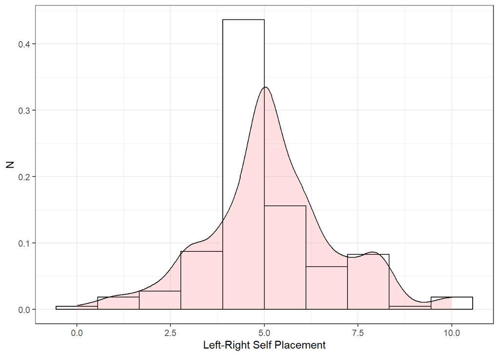

```r
df %>%
  mutate(lr=unclass(links_rechts))%>%
  select(lr)%>%
  ggplot()+
    aes(x=lr) +
    geom_histogram(aes(y=..density..), colour="black", fill="white", bins=10)+
    geom_density(alpha=.2, fill="#FF6666") +
    labs(x="Left-Right Self Placement", y="N")+
    theme_bw()
```

Seems roughly normally distributed. Wondering if too many right-wing people in the sample though - since we are looking at outgroups?

### Sociodemographics

```r
 df %>%
  mutate(gender=as_factor(geschlecht),
         edu=as_factor(schulabschluss))%>%
  select(gender,haushalteinkommen,edu)%>%
  summary()
```

```
##       gender    haushalteinkommen edu
##  Weiblich: 96   Min.   :    0     2:42
##  Männlich:100   1st Qu.: 1500     3:90
##  Divers  :  0   Median : 2200     4:20
##                 Mean   : 3274     5:43
##                 3rd Qu.: 3400     7: 1
##                 Max.   :45000
```

Equal on gender. Coding of Education is a bit coarse / no labels. Also some funny outliers on Income.

# Treatment Checks

## Basic Treatment Checks

### To what extent do you share the same opinion as the opinion depicted?

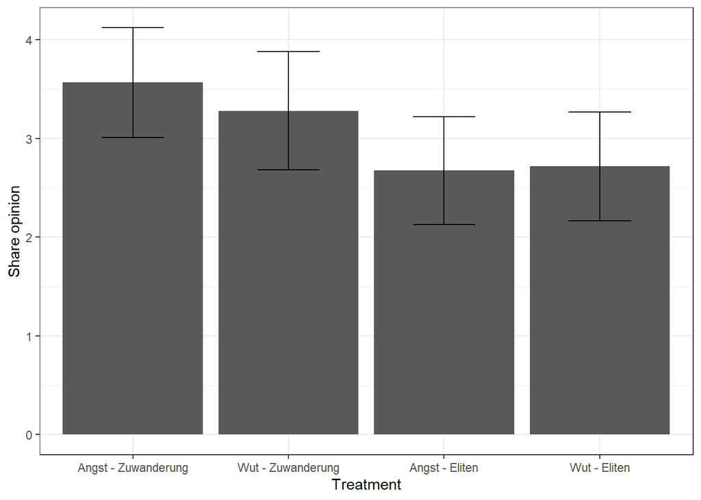

```r
  df %>%
    summarySE(data=., measurevar = "pt_eins_teilen", group= "treatment", na.rm=T)%>%
    ggplot()+
      aes(x=treatment,y=pt_eins_teilen,ymin=pt_eins_teilen-ci, ymax=pt_eins_teilen+ci)+
      geom_col()+
      geom_errorbar(width=0.4)+
      theme_bw()+
      labs(x="Treatment",y="Share opinion")
```

### To what extent can you understand the opinion depicted?

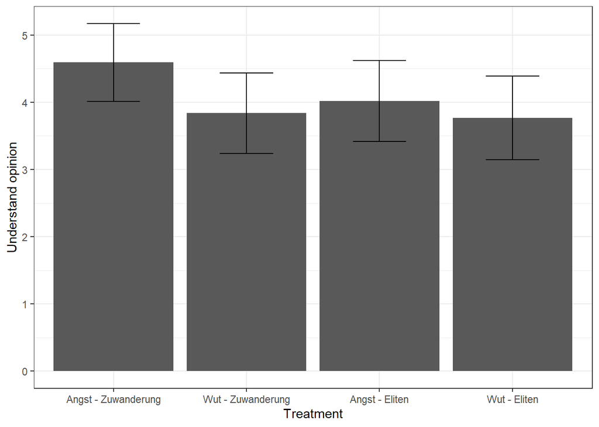

```r
  df %>%
    summarySE(data=., measurevar = "pt_eins_nachvollziehen", group= "treatment", na.rm=T)%>%
    ggplot()+
      aes(x=treatment,y=pt_eins_nachvollziehen,ymin=pt_eins_nachvollziehen-ci, ymax=pt_eins_nachvollziehen+ci)+
      geom_col()+
      geom_errorbar(width=0.4)+
      theme_bw()+
      labs(x="Treatment",y="Understand opinion")
```

# Power Analysis

Since we do not have a good expectation from the literature what our effect sizes might be, I am using the effect sizes observed in our pre-test to see if our planned sample size is sufficient to detect a statistically signficiant result. This is technically speaking not quite “proper”, but given no good theoretical grounding, I am using this as an exploratory tool. I am focusing only on the “main” study - that is, too what extent respondents can empathize/understand these fears/angers.

Let us try and aim for 80 % power

Alpha level of: 0.05

```r
 effect_size<-df %>%
    mutate(emotion=str_split_fixed(treatment, " - ",n=2)[,1],
           reason=str_split_fixed(treatment, " - ",n=2)[,2])%>%
    select(emotion,reason,pt_eins_nachvollziehen)%>%
    group_by(emotion,reason)%>%
    summarize(mean=mean(pt_eins_nachvollziehen,na.rm=T),
              sd=sd(pt_eins_nachvollziehen,na.rm=T))%>%
    pivot_wider(names_from=emotion, values_from=c(mean,sd))%>%
    mutate(effect=mean_Angst-mean_Wut,
           sd=mean(sd_Angst+sd_Wut)/2)%>%
    mutate(effect.std=effect/sd)
  effect_size
```

```
## # A tibble: 2 x 8
##   reason      mean_Angst mean_Wut sd_Angst sd_Wut effect    sd effect.std
##   <chr>            <dbl>    <dbl>    <dbl>  <dbl>  <dbl> <dbl>      <dbl>
## 1 Eliten            4.02     3.77     2.16   2.24  0.25   2.09      0.120
## 2 Zuwanderung       4.59     3.84     2.01   1.95  0.755  2.09      0.361
```

With standardized effect sizes of `0.1197148` for elites and `0.3613602` immigration respectively, we are roughly moving in the small / medium effect size category.

## Correlation power test

```r
pwr.r.test(
  r = effect_size$effect.std[2],
  sig.level = 0.05,
  power = 0.8)
```

```
##
##      approximate correlation power calculation (arctangh transformation)
##
##               n = 56.96953
##               r = 0.3613602
##       sig.level = 0.05
##           power = 0.8
##     alternative = two.sided
```

```r
pwr.r.test(
  r = effect_size$effect.std[1],
  sig.level = 0.05,
  power = 0.8)
```

```
##
##      approximate correlation power calculation (arctangh transformation)
##
##               n = 544.5257
##               r = 0.1197148
##       sig.level = 0.05
##           power = 0.8
##     alternative = two.sided
```

The sample sizes for elite effects are much larger than for immigration effects. I am also weary now about merging the two treatments. This also does not take into account the need for potential post treatment adjustment, such as controlling for relative proximity prior to treatment , based for example on left-right self treatment.